# What are the factors most significantly affecting world bliss?

### Introduction

The World Happiness Report is an annual report by the UN that measures the state of worldwide bliss. It is released on March 20th annually, the International Day of Happiness. The report is a landmark survey that ranks 156 nations by how happy their citizens perceive themselves to be. The report examines how factors such as governments, organizations and respectful society affects levels of overall happiness. By estimating a nation's level of well being, we can begin to determine levels of advancement. The goal of the report is to “give more importance to happiness and well-being in determining how to achieve and measure social and economic development.” By understanding how different environments such as social, enviornmental and natural living conditions affect prosperity, the foundation hopes to examine the evolution of world bliss. Moreover, it takes into account extensively how technologies, social norms, conflicts and government policies that have driven changes in prosperity over the years. If readers are interested in reading the latest World Happiness Report it can be found here: https://worldhappiness.report/ed/2020/

### What actually constitutes a happiness score?

Since happiness is not generally considered a quantifiable variable, you might be wondering how exactly the UN devises such a score. The score is actually composed from the Gallup World Poll datasets and used seven factors in its calculation. For each factor, (or variable), individuals rank their scores from 0 to 10. The scores are then normalized as well as compared against a dystopia, (a hypothetical nation with the lowest score in each category).

We will attempt to determine which factors are most significant in determining the happiness score for a particular nation by examining the data sets of the World Happiness Report over the course of six years and then make predictions about data throughout the years. After we figure our which of the seven variables are most influential in determining comparative rank, we will use linear regression models to attempt to make predict the actual scores in 156 nations. Our goal will be to go through the steps of data analysis including data collection, data tidying, data analysis and hypothesis testing.

We will be using Jupyter Notebooks to perform the data analysis using the following tools:

Pandas (https://pandas.pydata.org/docs/)

Numpy (https://numpy.org/doc/stable/)

Scikit-learn (https://scikit-learn.org/stable/)

Matplotlib (https://matplotlib.org/contents.html)

Our datasets will come from https://www.kaggle.com/mathurinache/world-happiness-report.

## Data Collection and Preparation

We must begin by downloading the dataset from the above URL. From this source, we will receive a series of 6 .csv files which we then import into our Jupyter Notebooks so that we can begin a proper data analysis. The six files pertain to the past six years of reports. Here, we will examine all together in order to form a holistic consensus.

```python
#import necessary libraries
import pandas as pd
import numpy as np
import matplotlib.pyplot as plt
```

```python
#load the csv files into dataframes
df1 = pd.read_csv('2015.csv')
df2 = pd.read_csv('2016.csv')
df3 = pd.read_csv('2017.csv')
df4 = pd.read_csv('2018.csv')
df5 = pd.read_csv('2019.csv')
df6 = pd.read_csv('2020.csv')

#Add a year column to each data frame
df1['Year'] = 2015
df2['Year'] = 2016
df3['Year'] = 2017
df4['Year'] = 2018
df5['Year'] = 2019
df6['Year'] = 2020
```

```python
df1.head()
```

|  | Country | Region | Happiness Rank | Happiness Score | Standard Error | Economy (GDP per Capita) | Family | Health (Life Expectancy) | Freedom | Trust (Government Corruption) | Generosity | Dystopia Residual | Year |
| --- | --- | --- | --- | --- | --- | --- | --- | --- | --- | --- | --- | --- | --- |
| 0 | Switzerland | Western Europe | 1 | 7.587 | 0.03411 | 1.39651 | 1.34951 | 0.94143 | 0.66557 | 0.41978 | 0.29678 | 2.51738 | 2015 |
| 1 | Iceland | Western Europe | 2 | 7.561 | 0.04884 | 1.30232 | 1.40223 | 0.94784 | 0.62877 | 0.14145 | 0.43630 | 2.70201 | 2015 |
| 2 | Denmark | Western Europe | 3 | 7.527 | 0.03328 | 1.32548 | 1.36058 | 0.87464 | 0.64938 | 0.48357 | 0.34139 | 2.49204 | 2015 |
| 3 | Norway | Western Europe | 4 | 7.522 | 0.03880 | 1.45900 | 1.33095 | 0.88521 | 0.66973 | 0.36503 | 0.34699 | 2.46531 | 2015 |
| 4 | Canada | North America | 5 | 7.427 | 0.03553 | 1.32629 | 1.32261 | 0.90563 | 0.63297 | 0.32957 | 0.45811 | 2.45176 | 2015 |

#### Data Overview

If we observe the first few rows of the dataset from 2015, we can see that we are provided with critical information regarding each country. We now begin the process of tidying and placing all data into a single data frame.

Thee data set is equipped with a number of columns containing valuable information about the nation and its corresponding happiness score. We hope that through the use of such figures we will be able to make quantifying predictions about the happiness scores seen above.

```python
#Tidy the data

#Store the countries and corresponding regions in a key for later use.
regions = df1[['Country', 'Region']]
```

In tidying our data we want to remove columns that will not be useful to our analysis. This includes columns such as upper and lower confidence intervals as well as standard error. We will be using our analysis to make predictions about happiness scores, so the only data we wish to concentrate upon are the columns directly used to actually calculate the score for each nation.

```python
#Remove the unnecessary columns from each data frame and rename the columns consistently

df1 = df1.drop(['Standard Error', 'Region'], axis=1)

df2 = df2.drop(['Lower Confidence Interval', 'Upper Confidence Interval', 'Region'], axis = 1)

df3 = df3.drop(['Whisker.high', 'Whisker.low'], axis=1)
df3.columns = df1.columns

df4['Residual'] = ''
df4 = df4[['Country or region', 'Overall rank', 'Score', 'GDP per capita', 'Social support', 'Healthy life expectancy',
         'Freedom to make life choices', 'Perceptions of corruption', 'Generosity', 'Residual','Year']]
df4.columns = df1.columns

df5['Residual'] = ''
df5 = df5[['Country or region', 'Overall rank', 'Score', 'GDP per capita', 'Social support', 'Healthy life expectancy',
         'Freedom to make life choices', 'Perceptions of corruption', 'Generosity', 'Residual','Year']]
df5.columns = df1.columns

df6['Happiness Rank'] = df6.index + 1
df6 = df6[['Country name', 'Happiness Rank','Ladder score', 'Explained by: Log GDP per capita', 'Explained by: Social support',
          'Explained by: Healthy life expectancy', 'Explained by: Freedom to make life choices', 'Explained by: Perceptions of corruption', 'Explained by: Generosity', 'Dystopia + residual', 'Year']]
df6.columns = df1.columns
```

```python
#Combine the dataframes into a single data frame
frames = [df1, df2, df3, df4, df5, df6]
data = pd.concat(frames)

#Add a region column and each country to their corresponding region

reg_dict = regions.set_index('Country').to_dict()['Region']
data['Region'] = data['Country'].map(reg_dict)

#The completed dataframe
data
```

|  | Country | Happiness Rank | Happiness Score | Economy (GDP per Capita) | Family | Health (Life Expectancy) | Freedom | Trust (Government Corruption) | Generosity | Dystopia Residual | Year | Region |
| --- | --- | --- | --- | --- | --- | --- | --- | --- | --- | --- | --- | --- |
| 0 | Switzerland | 1 | 7.5870 | 1.396510 | 1.349510 | 0.941430 | 0.665570 | 0.419780 | 0.296780 | 2.51738 | 2015 | Western Europe |
| 1 | Iceland | 2 | 7.5610 | 1.302320 | 1.402230 | 0.947840 | 0.628770 | 0.141450 | 0.436300 | 2.70201 | 2015 | Western Europe |
| 2 | Denmark | 3 | 7.5270 | 1.325480 | 1.360580 | 0.874640 | 0.649380 | 0.483570 | 0.341390 | 2.49204 | 2015 | Western Europe |
| 3 | Norway | 4 | 7.5220 | 1.459000 | 1.330950 | 0.885210 | 0.669730 | 0.365030 | 0.346990 | 2.46531 | 2015 | Western Europe |
| 4 | Canada | 5 | 7.4270 | 1.326290 | 1.322610 | 0.905630 | 0.632970 | 0.329570 | 0.458110 | 2.45176 | 2015 | North America |
| ... | ... | ... | ... | ... | ... | ... | ... | ... | ... | ... | ... | ... |
| 148 | Central African Republic | 149 | 3.4759 | 0.041072 | 0.000000 | 0.000000 | 0.292814 | 0.028265 | 0.253513 | 2.8602 | 2020 | Sub-Saharan Africa |
| 149 | Rwanda | 150 | 3.3123 | 0.343243 | 0.522876 | 0.572383 | 0.604088 | 0.485542 | 0.235705 | 0.548445 | 2020 | Sub-Saharan Africa |
| 150 | Zimbabwe | 151 | 3.2992 | 0.425564 | 1.047835 | 0.375038 | 0.377405 | 0.080929 | 0.151349 | 0.841031 | 2020 | Sub-Saharan Africa |
| 151 | South Sudan | 152 | 2.8166 | 0.289083 | 0.553279 | 0.208809 | 0.065609 | 0.111157 | 0.209935 | 1.37875 | 2020 | NaN |
| 152 | Afghanistan | 153 | 2.5669 | 0.300706 | 0.356434 | 0.266052 | 0.000000 | 0.001226 | 0.135235 | 1.50724 | 2020 | Southern Asia |

935 rows × 12 columns

Now that we have tidied our data, we can begin our analysis on the data set. The first thing we would like to observe is how average well-being changed annually. Rather than plotting all 156 countries trends, we will categorize each country by region and plot the annual change in happiness score per region so that we can observe trends. At first glance we can see that the top three nations of 2015 were Switzerland, Iceland and Denmark and all three shared the same region of Western Europe.

Our columns include Happiness Rank, Happiness Score, GDP, Family and Social Status, Life Expectancy, Freedom, Government Corruption, Generosity and Dystopia Residual.

Let us define our variables:

Happiness Rank pertains the nations rank comparative to other nations being assessed.

Happiness Score is calculated by adding the normalized rankings of the nations scores in each category.

Economy (GDP per Capita) is where individuals rate their happiness in life based on their earnings.

Family is where individuals rank the quality of their family lives.

Health (Life Expectancy) is determined by how available health care is in the nation and life expectancy.

Freedom pertains to how much independence a person is able to enjoy in his daily life.

Trust (Government Corruption) is ranked by how trusting the individual is of his or her government not to be corrupt.

Generosity involves how willing the individual's nation is in aiding worldly affairs such as peace keeping.

Dystopia Residual is calculated by adding the nation's residual with the score of a hypothetical nation with lowest scores.

```python
data.describe()
```

|  | Happiness Rank | Happiness Score | Economy (GDP per Capita) | Family | Health (Life Expectancy) | Freedom | Trust (Government Corruption) | Generosity | Year |
| --- | --- | --- | --- | --- | --- | --- | --- | --- | --- |
| count | 935.000000 | 935.000000 | 935.000000 | 935.000000 | 935.000000 | 935.000000 | 934.000000 | 935.000000 | 935.000000 |
| mean | 78.420321 | 5.394436 | 0.908311 | 1.091028 | 0.625581 | 0.419680 | 0.146840 | 0.193281 | 2017.485561 |
| std | 45.021905 | 1.124935 | 0.402023 | 0.324069 | 0.250900 | 0.152199 | 0.121378 | 0.117213 | 1.708260 |
| min | 1.000000 | 2.566900 | 0.000000 | 0.000000 | 0.000000 | 0.000000 | 0.000000 | 0.000000 | 2015.000000 |
| 25% | 39.500000 | 4.540000 | 0.600264 | 0.879945 | 0.449596 | 0.317835 | 0.060000 | 0.104985 | 2016.000000 |
| 50% | 78.000000 | 5.353500 | 0.974380 | 1.143945 | 0.667465 | 0.436000 | 0.106759 | 0.178660 | 2017.000000 |
| 75% | 117.000000 | 6.198500 | 1.228785 | 1.347408 | 0.814710 | 0.539885 | 0.193584 | 0.257824 | 2019.000000 |
| max | 158.000000 | 7.808700 | 2.096000 | 1.644000 | 1.141000 | 0.724000 | 0.838075 | 0.819710 | 2020.000000 |

This table gives us slightly more information about our data and points us to some quick facts about our dataset. The mean happiness score was 5.394436, while the min was 2.5669 and the max was 7.808. As we can tell, there is an evident disparity among our dataset.

## Data Analysis and Visualization

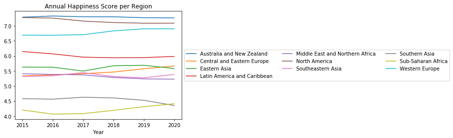

```python
%matplotlib inline

#Group the data by region and year to find annual averages based on region
plot = data.groupby(['Region', 'Year']).agg({'Happiness Score': ['mean']})
plot.columns = ['Happiness Score Mean']

#Unstack the data to reformat it
plot = plot.unstack(level='Region')
plot.columns = plot.columns.droplevel()

show = plot.plot(title= "Annual Happiness Score per Region")

show.legend(loc='center left', bbox_to_anchor=(1, 0.5), ncol = 3)
```

As we observe the trends, we can see that there is no significant flunctuation between average happiness scores over the years, with each region maintaining primarily flat slopes. Regions such as Sub-Saharan Africa and Southern Asian typically have lower happiness scores, wherease regions such as Australia and New Zealand as well as North America have consistently higher scores.

Since each region displays a fairly consistent trend throughout the years, let's observe the factors most influencing scores for the most recent year, 2020.

```python
#Get the rows which have the value '2020' for the data frame.
df = data.loc[data['Year'] == 2020]
df['Dystopia Residual'] = pd.to_numeric(df['Dystopia Residual'])


#Categorize them by region and take the mean of each factor
bar_graph = df.groupby(['Region']).agg({'Happiness Score': ['mean'], 'Economy (GDP per Capita)': ['mean'],
                                      'Family': ['mean'], 'Health (Life Expectancy)': ['mean'], 'Freedom': ['mean'],
                                       'Trust (Government Corruption)': ['mean'], 'Generosity': ['mean'],
                                       'Dystopia Residual': ['mean']})
bar_graph.columns = ['Happiness Score Mean', 'GDP Mean', 'Family Mean', 'Life Expectancy Mean', 'Freedom Mean', 'Corruption Mean', 'Generosity Mean', 'Dystopia Residual Mean']

#Display the averages for each category by region
bar_graph
```

| Region | Happiness Score Mean | GDP Mean | Family Mean | Life Expectancy Mean | Freedom Mean | Corruption Mean | Generosity Mean | Dystopia Residual Mean |
| --- | --- | --- | --- | --- | --- | --- | --- | --- |
| Australia and New Zealand | 7.261200 | 1.276357 | 1.482182 | 1.015373 | 0.634334 | 0.398632 | 0.325350 | 2.128956 |
| Central and Eastern Europe | 5.666379 | 0.980971 | 1.293696 | 0.775215 | 0.454706 | 0.082612 | 0.147890 | 1.931288 |
| Eastern Asia | 5.580825 | 1.101858 | 1.264228 | 0.894615 | 0.428033 | 0.109956 | 0.137231 | 1.644917 |
| Latin America and Caribbean | 5.981786 | 0.871039 | 1.269381 | 0.774657 | 0.520302 | 0.086553 | 0.151457 | 2.308386 |
| Middle East and Northern Africa | 5.227159 | 0.998307 | 1.127260 | 0.724121 | 0.375862 | 0.112388 | 0.143173 | 1.746049 |
| North America | 7.085850 | 1.337817 | 1.420089 | 0.927060 | 0.589318 | 0.251993 | 0.289836 | 2.269697 |
| Southeastern Asia | 5.383367 | 0.890821 | 1.191915 | 0.702408 | 0.618563 | 0.148924 | 0.306065 | 1.524672 |
| Southern Asia | 4.355083 | 0.591046 | 0.839690 | 0.572069 | 0.433323 | 0.097182 | 0.221899 | 1.599863 |
| Sub-Saharan Africa | 4.411611 | 0.435398 | 0.853093 | 0.358874 | 0.394180 | 0.106545 | 0.197513 | 2.066010 |
| Western Europe | 6.899219 | 1.300418 | 1.402224 | 0.995932 | 0.549439 | 0.262678 | 0.224752 | 2.163781 |

We will plot a stacked bar graph to display the average makeup of each happiness score based on region.

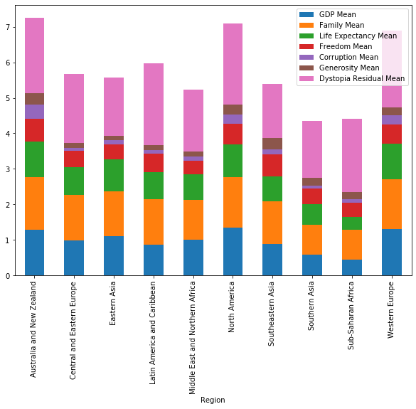

```python
#Plot the stacked bar graph
bar_graph.loc[:,bar_graph.columns[1:]].plot.bar(stacked=True, figsize=(10,7))
```

In determining the makeup of the average happiness scores for each region, it appears that the most significant factor in determining the score is the Dystopia Residual as this accounts for the greatest proportion of the score. While this factor makes up the greatest proportion consistently, it is not the one with the greatest flunctuation and is likely not the greatest cause of differences between scores. The factor that seems to have greatest flunctuation among scores is the Economy(GDP per Capita). Every other factor has relatively consistent flunctuations.

We can observe the trend associated with Economy GDP per Capita by plotting this value against our happiness ranks.

We will employ a similar strategy as above, but now on the entire data set. We will accomplish this by grouping columns by rank, and calculating the average GDP for each rank throughout all the years of data. We will then plot the results to see if we can observe any blatant trends.

[figure not shown]

```python
#Group data set by happiness rank and take the average GDP of each rank
pl = data.groupby(['Happiness Rank']).agg({'Economy (GDP per Capita)': ['mean']})
pl.columns = ['GDP Mean']

#Plot the happiness rank vs GDP Mean

pl.plot(title= "Annual Happiness Score per Region", figsize=(10, 8))
```

Observing the plot, there is a very clear trend between the Happiness Rank and mean GDP from the years 2015-2020. (Nations with higher happiness scores have lower ranks). This shows that GDP is likely one of the most significant factors in determining the happiness score of a nation. In fact, it may be possible that there is a linear relationship between GDP and happiness scores. To explain the graph, we treat Happiness Rank as the independent variable and GDP as the dependent variable.

We will now use linear regression to determine if our hypothesis is correct. Then, we will create a predictive model for happiness score based on the predictor variables in our dataset by observing the correlation between different factors.

## Hypothesis Testing and Machine Learning

In a simple linear regression model, we use a single linear variable to predict the value of a dependent variable. Multiple linear regression involves observing the effects of multiple indpendent variables on a dependent variable. We are attempting to measure the extent to which there exists a linear relationship between variables.

Let's first observe a simple linear regression model between GDP and predicted Happiness Scores.

```python
#Import necessary libraries
import numpy as np
from sklearn import linear_model
from scipy import stats
import statsmodels.api as sm
from statsmodels.formula.api import ols
import plotnine
from plotnine import *
%matplotlib inline

df.rename(columns = {'Economy (GDP per Capita)':'GDP', 'Happiness Score':'HapScore',
                    'Health (Life Expectancy)': 'lifeExp'}, inplace = True)

model = ols(formula='HapScore ~ GDP', data=df).fit()
model.summary()
```

OLS Regression Results

| Dep. Variable: | HapScore | R-squared: | 0.601 |
| --- | --- | --- | --- |
| Model: | OLS | Adj. R-squared: | 0.599 |
| Method: | Least Squares | F-statistic: | 227.6 |
| Date: | Mon, 20 Jul 2020 | Prob (F-statistic): | 5.98e-32 |
| Time: | 20:17:43 | Log-Likelihood: | -162.55 |
| No. Observations: | 153 | AIC: | 329.1 |
| Df Residuals: | 151 | BIC: | 335.2 |
| Df Model: | 1 |  |  |
| Covariance Type: | nonrobust |  |  |

|  | coef | std err | t | P>\|t\| | [0.025 | 0.975] |
| --- | --- | --- | --- | --- | --- | --- |
| Intercept | 3.4614 | 0.145 | 23.871 | 0.000 | 3.175 | 3.748 |
| GDP | 2.3158 | 0.153 | 15.088 | 0.000 | 2.013 | 2.619 |

| Omnibus: | 2.646 | Durbin-Watson: | 1.113 |
| --- | --- | --- | --- |
| Prob(Omnibus): | 0.266 | Jarque-Bera (JB): | 2.697 |
| Skew: | -0.297 | Prob(JB): | 0.260 |
| Kurtosis: | 2.737 | Cond. No. | 4.89 |

Warnings:  
[1] Standard Errors assume that the covariance matrix of the errors is correctly specified.

Above, we fit a linear regression model to our data, corresponding to the most recent data set of 2020. We then printed a summary of our data. From our results, we can state that the Happiness Score on average increases by 2.3158 for every increase in GDP. The results also allow us to reject our null hypothesis, that there is no relationship between GDP and happiness, because of the extremely low p-value 5.98e-32 which represents the possibility of our null hypothesis being true.

### Interpret the Linear Model Table

The table produced as a summary of our linear regression model is extremely extensive. Let's examine what information it contains:

The first cell listed tells us what our dependent variable is, in this case our happiness score. The model type is also listed as OLS, "Ordinary Least Squares", which simply indicates that the regression line we are attempting to fit minimizes the square of the distance from the true data to the regression line. Degrees of freedom is what DF Residuals and Model relate too, indicating that there are 151 values in the final model that are variant.

The coefficient of 2.3158 indicates that for every increase of 1 in GDP, our Happiness Score, the dependent variable, increases by 2.3158. Our R-squared value of 0.601 shows how much, in percentage, of variance can be explained by our model. This indicates that GDP is signficantly significant in predicting Happiness Scores. We are also provided figures for t-test and p-value used in hypothesis testing. Additionally, we are given a 95% confidence interval of (2.013, 2.619), that our true GDP coefficient falls within this range.

We will make a plot of our regression line below in order visualize the interaction between GDP and Happiness Score for our data set.

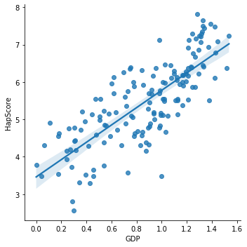

```python
import seaborn as sns
sns.lmplot(x='GDP',y='HapScore',data=df,fit_reg=True)
```

Now, let us determine if factors such as region may significantly effect Happiness Score by plotting individual regression lines for each region. By observing the differences between such regression lines, we can determine whether or not it is necessary to add an interaction term for each region.

We will now make a scatter plot of Happiness Score vs. GDP, grouped by Region, and add a regression line.

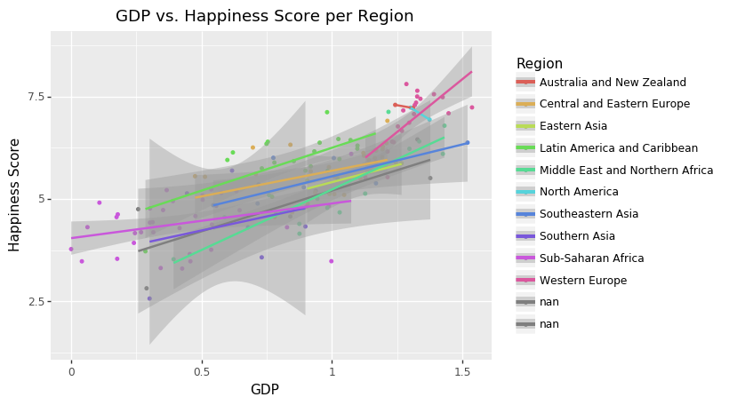

```python
ggplot(aes(x='GDP', y='HapScore', color='Region'), data=df) +\
    geom_point(size=1)+\
    stat_smooth(method = "lm", se=True, span=0.2) +\
    labs(title="GDP vs. Happiness Score per Region",
         x = "GDP",
         y = "Happiness Score")
```

### Multiple Linear Regression

Multiple Linear Regression involves observing how more than one independent variable affects a dependent variable. Previously, we observed the linear regression model of the single independent variable, GDP, on Happiness Score. What if we were to add a second variable such as life expectancy to our model to see if we can improve accuracy? What about a third variable such as family? We have chosen these variables due to the results from our above figures, indicating that such factors makeup a significant proportion of our happiness scores.

Let us execute this and determine if there is a significant improvement in the accuracy of our predictions.

```python
#Fit linear regression model based on multiple variables to obtain best fit

regr = ols(formula='HapScore ~ GDP + lifeExp + Family ', data=df).fit()
out = regr.summary()
out
```

OLS Regression Results

| Dep. Variable: | HapScore | R-squared: | 0.690 |
| --- | --- | --- | --- |
| Model: | OLS | Adj. R-squared: | 0.684 |
| Method: | Least Squares | F-statistic: | 110.7 |
| Date: | Mon, 20 Jul 2020 | Prob (F-statistic): | 9.63e-38 |
| Time: | 20:17:46 | Log-Likelihood: | -143.20 |
| No. Observations: | 153 | AIC: | 294.4 |
| Df Residuals: | 149 | BIC: | 306.5 |
| Df Model: | 3 |  |  |
| Covariance Type: | nonrobust |  |  |

|  | coef | std err | t | P>\|t\| | [0.025 | 0.975] |
| --- | --- | --- | --- | --- | --- | --- |
| Intercept | 2.3595 | 0.223 | 10.600 | 0.000 | 1.920 | 2.799 |
| GDP | 0.7383 | 0.285 | 2.594 | 0.010 | 0.176 | 1.301 |
| lifeExp | 1.3271 | 0.388 | 3.416 | 0.001 | 0.559 | 2.095 |
| Family | 1.3437 | 0.292 | 4.601 | 0.000 | 0.767 | 1.921 |

| Omnibus: | 1.243 | Durbin-Watson: | 1.225 |
| --- | --- | --- | --- |
| Prob(Omnibus): | 0.537 | Jarque-Bera (JB): | 1.179 |
| Skew: | -0.077 | Prob(JB): | 0.555 |
| Kurtosis: | 2.599 | Cond. No. | 17.0 |

Warnings:  
[1] Standard Errors assume that the covariance matrix of the errors is correctly specified.

This model has a higher R-Squared Value of 0.690 compared to our previous model, 0.601. The small increase shows that the two additional factors may not be as significant as GDP in predicting the happiness score. With there inclusion, our model still only explains 69.0% of the variance within out data.

### Hypothesis Testing

The next step is to verify our hypothesis, which can be accomplished by an f-test. Performing this test helps to verify the accuracy of our regression models and ensure that they fit the dataset well. We will perform an f-test on both the single linear regression and multiple linear regression models.

```python
#Perform f-test on single linear regression model
sm.stats.anova_lm(ols(formula='HapScore ~ GDP', data=df).fit(), typ=2)
```

|  | sum_sq | df | F | PR(>F) |
| --- | --- | --- | --- | --- |
| GDP | 113.054299 | 1.0 | 227.641085 | 5.983060e-32 |
| Residual | 74.991732 | 151.0 | NaN | NaN |

```python
#Perform f-test on multiple linear regression model
sm.stats.anova_lm(ols(formula='HapScore ~ GDP + lifeExp + Family', data=df).fit(), typ=2)
```

|  | sum_sq | df | F | PR(>F) |
| --- | --- | --- | --- | --- |
| GDP | 2.629424 | 1.0 | 6.727899 | 0.010439 |
| lifeExp | 4.560963 | 1.0 | 11.670123 | 0.000819 |
| Family | 8.271938 | 1.0 | 21.165386 | 0.000009 |
| Residual | 58.232758 | 149.0 | NaN | NaN |

#### Now we will use linear regression techniques to create a predictive model for happiness score using ALL given variables.

Rather than only determining which variable in most influential, we will attempt to create a line of best fit using all of our variables. To accomplish this using SKlearn, we need to drop any unnecessary variables in our data, (such as categorical variables).

```python
#Import LinearRegression from SKlearn
from sklearn.linear_model import LinearRegression

#Drop all categorical variables in the data set
predData = data.drop(["Country", "Happiness Rank", "Year", "Region"], axis=1)
predData = predData.rename(columns={"Happiness Score": "Happiness_Score"})

#Set all columns as numeric
predData = predData.apply(pd.to_numeric)

#Handle missing data
predData = predData.fillna(predData.mean())

X = predData.drop("Happiness_Score", axis = 1)
lm = LinearRegression()

#Fit the data
predModel = lm.fit(X, predData.Happiness_Score)
predModel
```

```
LinearRegression(copy_X=True, fit_intercept=True, n_jobs=None, normalize=False)
```

```python
coef = zip(X.columns, lm.coef_)
coDF = pd.DataFrame(list(zip(X.columns, lm.coef_)), columns=['variables', 'coef'])
coDF
```

|  | variables | coef |
| --- | --- | --- |
| 0 | Economy (GDP per Capita) | 1.059047 |
| 1 | Family | 0.902245 |
| 2 | Health (Life Expectancy) | 0.920647 |
| 3 | Freedom | 1.175224 |
| 4 | Trust (Government Corruption) | 1.060309 |
| 5 | Generosity | 0.876069 |
| 6 | Dystopia Residual | 0.996652 |

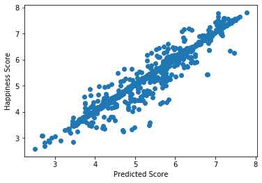

```python
#Plot our predicted model against our

plt.scatter(x = lm.predict(X), y = predData.Happiness_Score)
plt.xlabel("Predicted Score")
plt.ylabel("Happiness Score")
plt.show()
```

```python
#Print the mean absolute error.
np.mean((predData.Happiness_Score - lm.predict(X)) ** 2 )
```

```
0.09557770341870847
```

## Conclusion

From our techniques of data science analysis, we can draw conclusion about the reports on the World Happiness Report. The report examines levels of bliss for 156 nations and using such information, policy and advancement can be predicted as well as the factors that are most indicative of worldwide bliss.

#### Does this mean that we can always predict how happy the world will be in the future?

The short answer is no. Although we have data about past statistics, we cannot guarantee that accurate predictions about world bliss can be forecasted. There are always extraneous factors capable of greatly affecting happiness scores of individuals. For example, as result of the ongoing COVID-19 pandemic, many will face great risks in well-being and income. These factors will come heavily into play when we gauge the climate of world happiness in 2021.

If readers are more interested in finding information regarding worldwide levels of bliss, reports from 2012 to 2020 can be found at: https://worldhappiness.report.

The reports provide extensive information and figures regarding factors influencing world support and aim to account for living environments affect happiness.